# index

### GitHub Project Links

- [Solo Project: RShiny Dashboard Using Strava Data](https://colsco.shinyapps.io/strava_data_dashboard/)

  A RShiny dashboard build using my own activity data downloaded from the fitness tracking website strava.com. This is an intermittently updated, endless work in progress that I use it to try different layouts, fonts, and various packages relating to RShiny.

Trying different packages in this layout led me on to more specific geospatial coding which is detailed in the mapping project below.

[figure not shown]

- [Solo Project: Handling .gpx and .fit Files in R](https://github.com/colsco/cc_gpx_fit#readme)

  Being a keen cyclist with several years’ worth of ride data (above) I thought it would be interesting to be able to map rides from .gpx files including adding some representation of the route elevation.

This was achieved using the `plotKML` and `leaflet` packages to plot the route in the latitude/longitude space, then using the `Leaflet.hotline` javascript plug-in for R to use colour to represent the elevation at any given point.

A full write-up of the work can be found on github

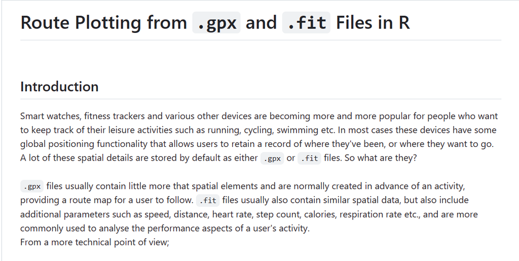

- [Group Project: RShiny Dashboard for Public Health Scotland](https://colsco.shinyapps.io/phs_rshiny_dashboard_project_group4/)

  A group project completed while studying on CodeClan’s Professional Data Analysis course, using open source data from Public Health Scotland with the aim of investigating NHS Scotland acute care hospitals and whether or not the data backed up the so-called “winter crisis”.

[figure not shown]